# Purtell_ProblemSet04

Author

Colin Purtell

## STATS 506 Problem Set 4:

Link to repository: https://github.com/cspurtell/stat506

### Problem 1

```r
library(tidyverse)
library(nzelect)
data("nzge")
```

#### a.

```r
nzge %>%
  group_by(election_year, voting_type) %>%
  summarize(total_votes = sum(votes, na.rm = TRUE)) %>%
  arrange(desc(total_votes))
```

```
# A tibble: 10 × 3
# Groups:   election_year [5]
   election_year voting_type total_votes
           <dbl> <chr>             <dbl>
 1          2014 Party           2416479
 2          2014 Candidate       2375493
 3          2008 Party           2356536
 4          2008 Candidate       2325598
 5          2005 Party           2286190
 6          2005 Candidate       2260670
 7          2011 Party           2257336
 8          2011 Candidate       2225766
 9          2002 Party           2040248
10          2002 Candidate       2022115
```

#### b.

```r
nzge %>%
  filter(election_year == 2014, voting_type == "Candidate") %>%
  group_by(party) %>%
  summarize(total_votes = sum(votes, na.rm = TRUE)) %>%
  mutate(percent = 100 * total_votes / sum(total_votes)) %>%
  arrange(desc(percent))
```

```
# A tibble: 25 × 3
   party                    total_votes percent
   <chr>                          <dbl>   <dbl>
 1 National Party               1081787  45.5
 2 Labour Party                  801287  33.7
 3 Green Party                   165718   6.98
 4 Conservative Party             81075   3.41
 5 New Zealand First Party        73384   3.09
 6 Maori Party                    42108   1.77
 7 MANA Movement                  32333   1.36
 8 Informal Candidate Votes       27886   1.17
 9 ACT New Zealand                27778   1.17
10 United Future                  14722   0.620
# ℹ 15 more rows
```

#### c.

```r
nzge %>%
  group_by(election_year, voting_type, party) %>%
  summarize(total_votes = sum(votes, na.rm = TRUE)) %>%
  slice_max(total_votes, n = 1, with_ties = FALSE) %>%
  pivot_wider(
    names_from = voting_type,
    values_from = party,
    names_prefix = "winner_"
  )
```

```
# A tibble: 10 × 4
# Groups:   election_year [5]
   election_year total_votes winner_Candidate winner_Party
           <dbl>       <dbl> <chr>            <chr>
 1          2002      891866 Labour Party     <NA>
 2          2002      838219 <NA>             Labour Party
 3          2005      902874 National Party   <NA>
 4          2005      935319 <NA>             Labour Party
 5          2008     1072024 National Party   <NA>
 6          2008     1053398 <NA>             National Party
 7          2011     1027696 National Party   <NA>
 8          2011     1058636 <NA>             National Party
 9          2014     1081787 National Party   <NA>
10          2014     1131501 <NA>             National Party
```

### Problem 2

```r
atp = read.csv("data/atp_matches_2019.csv")
```

#### a.

```r
atp %>%
  distinct(tourney_id, tourney_name) %>%
  count()
```

```
    n
1 128
```

#### b.

```r
tourney_winners = atp %>%
  filter(round == "F") %>%
  group_by(tourney_id, tourney_name) %>%
  summarize(winner = first(winner_name), .groups = "drop")
```

For consistency, I defined a ‘tournament’ as any event with a recorded final match (round == “F”). This ensures the champion is identifiable. Using this criterion, 67 tournaments had a final recorded in 2019.

```r
tourney_winners %>%
  count(winner, sort = TRUE)
```

```
# A tibble: 41 × 2
   winner                 n
   <chr>              <int>
 1 Dominic Thiem          5
 2 Novak Djokovic         5
 3 Daniil Medvedev        4
 4 Rafael Nadal           4
 5 Roger Federer          4
 6 Alex De Minaur         3
 7 Stefanos Tsitsipas     3
 8 Benoit Paire           2
 9 Cristian Garin         2
10 Jo-Wilfried Tsonga     2
# ℹ 31 more rows
```

```r
tourney_winners %>%
  count(winner, sort = TRUE) %>%
  filter(n > 1)
```

```
# A tibble: 12 × 2
   winner                 n
   <chr>              <int>
 1 Dominic Thiem          5
 2 Novak Djokovic         5
 3 Daniil Medvedev        4
 4 Rafael Nadal           4
 5 Roger Federer          4
 6 Alex De Minaur         3
 7 Stefanos Tsitsipas     3
 8 Benoit Paire           2
 9 Cristian Garin         2
10 Jo-Wilfried Tsonga     2
11 Matteo Berrettini      2
12 Nick Kyrgios           2
```

We can see that 12 players won more than one tournament, with the most being 5 by Dominic Thiem and Novak Djokovic.

#### c.

```r
aces_long <- atp %>%
  select(w_ace, l_ace) %>%
  rename(winner = w_ace, loser = l_ace) %>%
  pivot_longer(cols = c(winner, loser),
               names_to = "result",
               values_to = "aces") %>%
  filter(!is.na(aces))

aces_long %>%
  group_by(result) %>%
  summarise(
    mean_aces = mean(aces, na.rm = TRUE),
    median_aces = median(aces, na.rm = TRUE),
    sd_aces = sd(aces, na.rm = TRUE),
    n = n()
  )
```

```
# A tibble: 2 × 5
  result mean_aces median_aces sd_aces     n
  <chr>      <dbl>       <dbl>   <dbl> <int>
1 loser       5.79           4    5.63  2694
2 winner      7.50           6    6.07  2694
```

We can see from the observed mean and sd for each group of players that the mean number of aces for winners is higher than for losers.

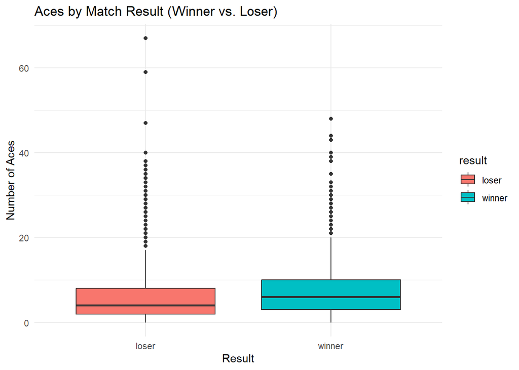

```r
aces_long %>%
  ggplot(aes(x = result, y = aces, fill = result)) +
  geom_boxplot() +
  labs(
    title = "Aces by Match Result (Winner vs. Loser)",
    x = "Result", y = "Number of Aces"
  ) +
  theme_minimal()
```

#### d.

```r
player_stats <- atp %>%
  select(winner_name, loser_name) %>%
  pivot_longer(
    cols = c(winner_name, loser_name),
    names_to = "result",
    values_to = "player"
  ) %>%
  mutate(win = if_else(result == "winner_name", 1, 0))

player_summary <- player_stats %>%
  group_by(player) %>%
  summarise(
    matches = n(),
    wins = sum(win),
    win_rate = wins / matches
  ) %>%
  filter(matches >= 5) %>%
  arrange(desc(win_rate))

player_summary %>%
  filter(win_rate == max(win_rate))
```

```
# A tibble: 1 × 4
  player       matches  wins win_rate
  <chr>          <int> <dbl>    <dbl>
1 Rafael Nadal      69    60    0.870
```

From the above filtering, we find that Rafael Nadal has the highest win rate of around 87%.

### Problem 3

```r
usa <- read.csv("data/us-states.csv") %>%
  mutate(date = as.Date(date))
```

#### a.

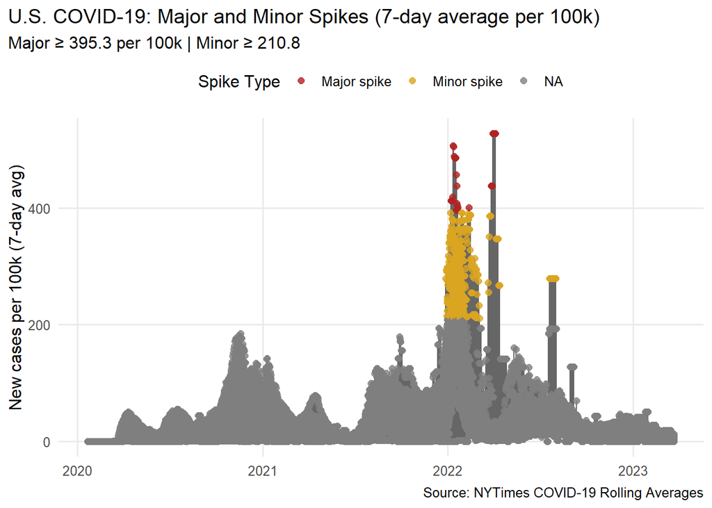

```r
max_cases <- max(usa$cases_avg_per_100k, na.rm = TRUE)
major_cutoff <- 0.75 * max_cases
minor_cutoff <- 0.40 * max_cases

usa_spikes <- usa %>%
  mutate(
    spike_type = case_when(
      cases_avg_per_100k >= major_cutoff ~ "Major spike",
      cases_avg_per_100k >= minor_cutoff ~ "Minor spike",
      TRUE ~ NA_character_
    )
  )

usa_spikes %>%
  ggplot(aes(x = date, y = cases_avg_per_100k)) +
  geom_line(color = "grey40") +
  geom_point(aes(color = spike_type), size = 2, alpha = 0.8, na.rm = TRUE) +
  scale_color_manual(values = c("Major spike" = "firebrick", "Minor spike" = "goldenrod")) +
  labs(
    title = "U.S. COVID-19: Major and Minor Spikes (7-day average per 100k)",
    subtitle = paste0("Major ≥ ", round(major_cutoff, 1), " per 100k | Minor ≥ ", round(minor_cutoff, 1)),
    x = NULL,
    y = "New cases per 100k (7-day avg)",
    color = "Spike Type",
    caption = "Source: NYTimes COVID-19 Rolling Averages"
  ) +
  theme_minimal(base_size = 12) +
  theme(
    legend.position = "top",
    plot.title.position = "plot",
    panel.grid.minor = element_blank()
  )
```

```r
spike_counts <- usa_spikes %>%
  mutate(
    is_spike = !is.na(spike_type),
    group_id = cumsum(is.na(lag(spike_type)) & !is.na(spike_type))
  ) %>%
  filter(is_spike) %>%
  group_by(spike_type, group_id) %>%
  summarise(
    start_date = min(date),
    end_date = max(date),
    .groups = "drop"
  ) %>%
  group_by(spike_type) %>%
  summarise(n_spikes = n(), .groups = "drop")

spike_counts
```

```
# A tibble: 2 × 2
  spike_type  n_spikes
  <chr>          <int>
1 Major spike       28
2 Minor spike      433
```

Using our definitions, we find 28 major spikes and 433 minor spikes.

#### b.

To keep it simple, we’ll use the average cases_avg_per_100k across the full dataset period for each state. This reflects the typical per-capita infection rate.

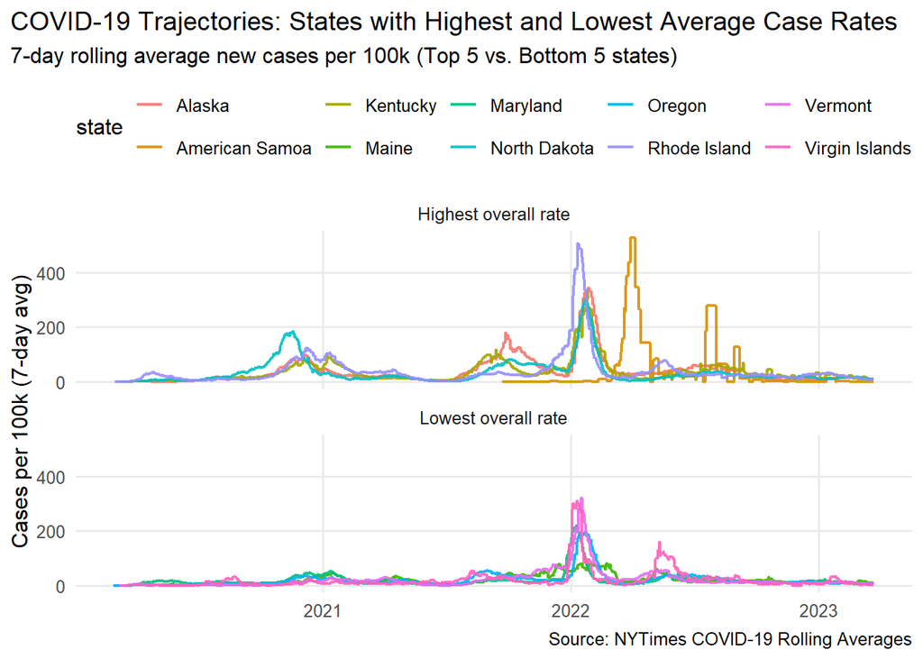

```r
state_rates <- usa %>%
  group_by(state) %>%
  summarise(mean_rate = mean(cases_avg_per_100k, na.rm = TRUE), .groups = "drop")

top_states <- state_rates %>% slice_max(mean_rate, n = 5) %>% pull(state)
bottom_states <- state_rates %>% slice_min(mean_rate, n = 5) %>% pull(state)

usa %>%
  filter(state %in% c(top_states, bottom_states)) %>%
  mutate(
    category = case_when(
      state %in% top_states ~ "Highest overall rate",
      state %in% bottom_states ~ "Lowest overall rate"
    )
  ) %>%
  ggplot(aes(x = date, y = cases_avg_per_100k, color = state, group = state)) +
  geom_line(size = 0.8, alpha = 0.9) +
  facet_wrap(~ category, ncol = 1, scales = "fixed") +
  labs(
    title = "COVID-19 Trajectories: States with Highest and Lowest Average Case Rates",
    subtitle = "7-day rolling average new cases per 100k (Top 5 vs. Bottom 5 states)",
    x = NULL,
    y = "Cases per 100k (7-day avg)",
    caption = "Source: NYTimes COVID-19 Rolling Averages"
  ) +
  theme_minimal(base_size = 12) +
  theme(
    legend.position = "top",
    plot.title.position = "plot",
    panel.grid.minor = element_blank()
  )
```

The five highest states/territories are American Samoa, Rhode Island, Alaska, Kentucky, and North Dakota, while the five lowest are Maryland, Maine, Oregon, the Virgin Islands, and Vermont. We can see that both groups share the same broad pandemic timeline with spikes in the same areas. The top and bottom groups differ dramatically in case magnitude, and there are some increases in average cases observed in the top group that are not seen in the bottom group.

#### c.

We can define when a state experiences COVID “in a substantial way” as when its 7-day average of new cases per 100k exceeds 1.0 for at least three consecutive days.

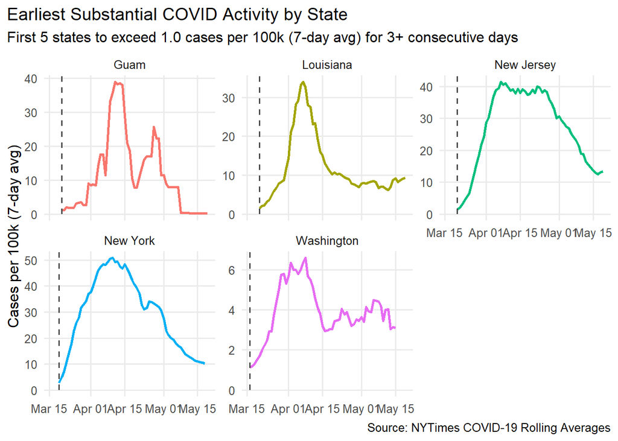

```r
first_substantial <- usa %>%
  group_by(state) %>%
  arrange(date, .by_group = TRUE) %>%
  mutate(
    above = cases_avg_per_100k >= 1.0,
    run = ave(above, cumsum(!above), FUN = seq_along)
  ) %>%
  filter(above & run >= 3) %>%
  summarise(first_date = min(date), .groups = "drop") %>%
  arrange(first_date)

first_five <- head(first_substantial, 5)

cov_plot <- usa %>%
  inner_join(first_five, by = "state") %>%
  filter(date >= first_date & date <= first_date + 60)

onset_lines <- first_five %>%
  mutate(first_date = as.Date(first_date))

ggplot(cov_plot, aes(x = date, y = cases_avg_per_100k, color = state)) +
  geom_line(linewidth = 1) +
  geom_segment(
    data = onset_lines,
    aes(
      x = first_date, xend = first_date,
      y = 0, yend = Inf
    ),
    inherit.aes = FALSE,
    color = "gray30", linetype = 2, linewidth = 0.7
  ) +
  facet_wrap(~ state, scales = "free_y") +
  labs(
    title = "Earliest Substantial COVID Activity by State",
    subtitle = "First 5 states to exceed 1.0 cases per 100k (7-day avg) for 3+ consecutive days",
    x = NULL,
    y = "Cases per 100k (7-day avg)",
    caption = "Source: NYTimes COVID-19 Rolling Averages"
  ) +
  theme_minimal(base_size = 12) +
  theme(
    legend.position = "none",
    plot.title.position = "plot",
    panel.grid.minor = element_blank()
  )
```

Using a simple rule of 1.0 cases per 100 000 (7-day average) sustained for at least three days, the first five states with substantial COVID-19 activity were Washington, Louisiana, New York, New Jersey, and Guam. Each panel shows a clear increase shortly after the dashed onset line, illustrating how quickly cases accelerated once community spread began.

#### Resources Used:

Tidyverse documentation for slice_max() and pivot_wider() functions, ggplot documentation for finding certain parameters, ChatGPT for debugging.